# CS 422

Kamen Petkov, Illinois Institute of Technology

### Libraries

```r
library(dplyr)
library(psych)
library(cluster)
library(factoextra)
library(dbscan)
library(fpc)
setwd("C:/Users/ACER/Desktop/Desktop/IIT_Stuff/CS 422/myHws/HW8")
```

### (a) Data Cleanup

```r
# Data that we're going to use
df <- read.table("file19.txt", skip = 20, header = TRUE)

# Show part of data
head(df)
```

|  | Name | I | i | C | c | P | p | M | m |
| --- | --- | --- | --- | --- | --- | --- | --- | --- | --- |
| 1 | Opossum | 5 | 4 | 1 | 1 | 3 | 3 | 4 | 4 |
| 2 | Hairy tail mole | 3 | 3 | 1 | 1 | 4 | 4 | 3 | 3 |
| 3 | Common mole | 3 | 2 | 1 | 0 | 3 | 3 | 3 | 3 |
| 4 | Star nose mole | 3 | 3 | 1 | 1 | 4 | 4 | 3 | 3 |
| 5 | Brown bat | 2 | 3 | 1 | 1 | 3 | 3 | 3 | 3 |
| 6 | Silver hair bat | 2 | 3 | 1 | 1 | 2 | 3 | 3 | 3 |

```r
# Find correlation between the attribute
cor(df[,-1])
```

```
           I          i          C          c          P          p          M          m
I  1.0000000  0.1659146  0.7208151  0.7736898  0.5013071  0.4741287 -0.5321054 -0.4276940
i  0.1659146  1.0000000  0.4609938  0.3795293  0.5990269  0.6640471 -0.1860646 -0.1291324
C  0.7208151  0.4609938  1.0000000  0.9114654  0.6414204  0.6981357 -0.5253975 -0.4523069
c  0.7736898  0.3795293  0.9114654  1.0000000  0.6001382  0.6475080 -0.5618217 -0.4794970
P  0.5013071  0.5990269  0.6414204  0.6001382  1.0000000  0.9319845 -0.5293310 -0.4665738
p  0.4741287  0.6640471  0.6981357  0.6475080  0.9319845  1.0000000 -0.4558752 -0.3801773
M -0.5321054 -0.1860646 -0.5253975 -0.5618217 -0.5293310 -0.4558752  1.0000000  0.9326689
m -0.4276940 -0.1291324 -0.4523069 -0.4794970 -0.4665738 -0.3801773  0.9326689  1.0000000
```

```r
# (i)
df$c = NULL
df$p = NULL
df$m = NULL

summary(df)
```

```
     Name                 I               i               C                P               M
 Length:66          Min.   :0.000   Min.   :0.000   Min.   :0.0000   Min.   :0.000   Min.   :0.000
 Class :character   1st Qu.:1.000   1st Qu.:1.000   1st Qu.:0.0000   1st Qu.:2.000   1st Qu.:1.000
 Mode  :character   Median :2.000   Median :3.000   Median :1.0000   Median :3.000   Median :3.000
                    Mean   :1.803   Mean   :2.379   Mean   :0.5909   Mean   :2.561   Mean   :2.455
                    3rd Qu.:3.000   3rd Qu.:3.000   3rd Qu.:1.0000   3rd Qu.:3.000   3rd Qu.:3.000
                    Max.   :5.000   Max.   :4.000   Max.   :1.0000   Max.   :4.000   Max.   :8.000
```

```r
# (ii) Standardize the data
df.scale <- scale(df[,-1])
summary(df.scale)
```

```
       I                 i                 C                 P                 M
 Min.   :-1.5119   Min.   :-2.0499   Min.   :-1.1927   Min.   :-2.1042   Min.   :-2.1052
 1st Qu.:-0.6734   1st Qu.:-1.1882   1st Qu.:-1.1927   1st Qu.:-0.4607   1st Qu.:-1.2475
 Median : 0.1652   Median : 0.5353   Median : 0.8257   Median : 0.3611   Median : 0.4678
 Mean   : 0.0000   Mean   : 0.0000   Mean   : 0.0000   Mean   : 0.0000   Mean   : 0.0000
 3rd Qu.: 1.0037   3rd Qu.: 0.5353   3rd Qu.: 0.8257   3rd Qu.: 0.3611   3rd Qu.: 0.4678
 Max.   : 2.6808   Max.   : 1.3971   Max.   : 0.8257   Max.   : 1.1828   Max.   : 4.7562
```

```r
# (iii)
write.csv(df,"file19.csv")
```

#### (i) Think of what attributes, if any, you may want to omit from the dataset when you do the clustering. Indicate all of the attributes you removed before doing the clustering.

#### Drop c,p,m since they are strongly correlated with C,P,M - we don’t need both.

#### (ii) Does the data need to be standardized?

#### In this case standardization might not be necessary since the difference between min and max is not too big. However, for the sake of making the work easier for the computer (algorithm is easier to use), I will scale.

### B) Clustering

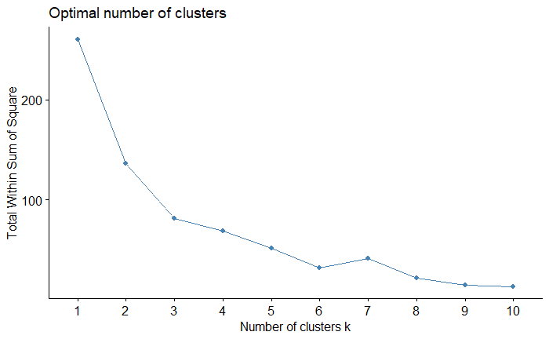

```r
fviz_nbclust(df.scale[, -1], kmeans, method = "wss")
```

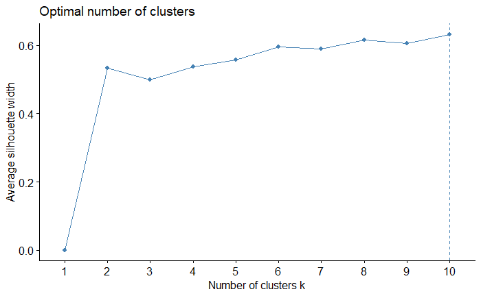

```r
fviz_nbclust(df.scale[, -1], kmeans, method = "silhouette")
```

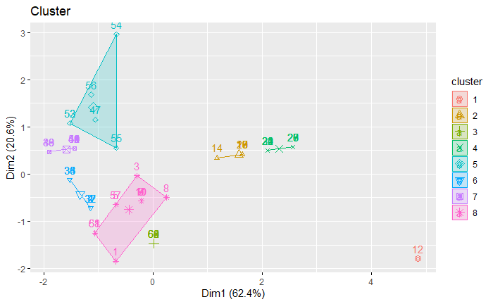

```r
# (ii) Once you have determined the number of clusters, run k-means clustering on the dataset to create that many
# clusters. Plot the clusters using fviz_cluster().

clst <- kmeans(df.scale[, -1], centers = 8, nstart = 25)
fviz_cluster(clst, df.scale[, -1], main = "Cluster")
```

```r
# (iii) How many observations are in each cluster?
clst$size
```

```
[1]  1  8  7 11  6  8 13 12
```

```r
# (iv) What is the total SSE of the clusters?
clst$totss
```

```
[1] 260
```

```r
clst$tot.withinss
```

```
[1] 17.57414
```

```r
# Total SSE of the clusters = 260
# Total within-clusters = 17.57414

# (v) What is the SSE of each cluster?
clst$withinss
```

```
[1] 0.000000e+00 5.908626e-01 3.882675e-31 1.841650e+00 5.083201e+00 1.471193e+00 1.869983e+00 6.717249e+00
```

```r
# (vi) Perform an analysis of each cluster to determine how the mammals are grouped in each cluster, and whether
# that makes sense?

df[which(clst$cluster == 1),]
```

|  | Name | I | i | C | P | M |
| --- | --- | --- | --- | --- | --- | --- |
| 12 | Armadillo | 0 | 0 | 0 | 0 | 8 |

```r
df[which(clst$cluster == 2),]
```

|  | Name | I | i | C | P | M |
| --- | --- | --- | --- | --- | --- | --- |
| 13 | Pika | 2 | 1 | 0 | 2 | 3 |
| 14 | Snowshoe rabbit | 2 | 1 | 0 | 3 | 3 |
| 15 | Beaver | 1 | 1 | 0 | 2 | 3 |
| 16 | Marmot | 1 | 1 | 0 | 2 | 3 |
| 17 | Groundhog | 1 | 1 | 0 | 2 | 3 |
| 18 | Prairie Dog | 1 | 1 | 0 | 2 | 3 |
| 19 | Ground Squirrel | 1 | 1 | 0 | 2 | 3 |
| 20 | Chipmunk | 1 | 1 | 0 | 2 | 3 |

```r
df[which(clst$cluster == 3),]
```

|  | Name | I | i | C | P | M |
| --- | --- | --- | --- | --- | --- | --- |
| 59 | Deer | 0 | 4 | 0 | 3 | 3 |
| 60 | Moose | 0 | 4 | 0 | 3 | 3 |
| 62 | Antelope | 0 | 4 | 0 | 3 | 3 |
| 63 | Bison | 0 | 4 | 0 | 3 | 3 |
| 64 | Mountain goat | 0 | 4 | 0 | 3 | 3 |
| 65 | Musk ox | 0 | 4 | 0 | 3 | 3 |
| 66 | Mountain sheep | 0 | 4 | 0 | 3 | 3 |

```r
df[which(clst$cluster == 4),]
```

|  | Name | I | i | C | P | M |
| --- | --- | --- | --- | --- | --- | --- |
| 21 | Gray squirrel | 1 | 1 | 0 | 1 | 3 |
| 22 | Fox squirrel | 1 | 1 | 0 | 1 | 3 |
| 23 | Pocket gopher | 1 | 1 | 0 | 1 | 3 |
| 24 | Kangaroo rat | 1 | 1 | 0 | 1 | 3 |
| 25 | Pack rat | 1 | 1 | 0 | 0 | 3 |
| 26 | Field mouse | 1 | 1 | 0 | 0 | 3 |
| 27 | Muskrat | 1 | 1 | 0 | 0 | 3 |
| 28 | Black rat | 1 | 1 | 0 | 0 | 3 |
| 29 | House mouse | 1 | 1 | 0 | 0 | 3 |
| 30 | Porcupine | 1 | 1 | 0 | 1 | 3 |

[output cut: 1 more lines]

```r
df[which(clst$cluster == 5),]
```

|  | Name | I | i | C | P | M |
| --- | --- | --- | --- | --- | --- | --- |
| 47 | Sea otter | 3 | 2 | 1 | 3 | 1 |
| 52 | Fur seal | 3 | 2 | 1 | 4 | 1 |
| 53 | Sea lion | 3 | 2 | 1 | 4 | 1 |
| 54 | Walrus | 1 | 0 | 1 | 3 | 0 |
| 55 | Grey seal | 3 | 2 | 1 | 3 | 2 |
| 56 | Elephant seal | 2 | 1 | 1 | 4 | 1 |

```r
df[which(clst$cluster == 6),]
```

|  | Name | I | i | C | P | M |
| --- | --- | --- | --- | --- | --- | --- |
| 2 | Hairy tail mole | 3 | 3 | 1 | 4 | 3 |
| 4 | Star nose mole | 3 | 3 | 1 | 4 | 3 |
| 32 | Coyote | 1 | 3 | 1 | 4 | 3 |
| 33 | Wolf | 3 | 3 | 1 | 4 | 2 |
| 34 | Fox | 3 | 3 | 1 | 4 | 2 |
| 35 | Bear | 3 | 3 | 1 | 4 | 2 |
| 36 | Civet cat | 3 | 3 | 1 | 4 | 2 |
| 37 | Raccoon | 3 | 3 | 1 | 4 | 3 |

```r
df[which(clst$cluster == 7),]
```

|  | Name | I | i | C | P | M |
| --- | --- | --- | --- | --- | --- | --- |
| 38 | Marten | 3 | 3 | 1 | 4 | 1 |
| 39 | Fisher | 3 | 3 | 1 | 4 | 1 |
| 40 | Weasel | 3 | 3 | 1 | 3 | 1 |
| 41 | Mink | 3 | 3 | 1 | 3 | 1 |
| 42 | Ferrer | 3 | 3 | 1 | 3 | 1 |
| 43 | Wolverine | 3 | 3 | 1 | 4 | 1 |
| 44 | Badger | 3 | 3 | 1 | 3 | 1 |
| 45 | Skunk | 3 | 3 | 1 | 3 | 1 |
| 46 | River otter | 3 | 3 | 1 | 4 | 1 |
| 48 | Jaguar | 3 | 3 | 1 | 3 | 1 |

[output cut: 3 more lines]

```r
df[which(clst$cluster == 8),]
```

|  | Name | I | i | C | P | M |
| --- | --- | --- | --- | --- | --- | --- |
| 1 | Opossum | 5 | 4 | 1 | 3 | 4 |
| 3 | Common mole | 3 | 2 | 1 | 3 | 3 |
| 5 | Brown bat | 2 | 3 | 1 | 3 | 3 |
| 6 | Silver hair bat | 2 | 3 | 1 | 2 | 3 |
| 7 | Pigmy bat | 2 | 3 | 1 | 2 | 3 |
| 8 | House bat | 2 | 3 | 1 | 1 | 3 |
| 9 | Red bat | 1 | 3 | 1 | 2 | 3 |
| 10 | Hoary bat | 1 | 3 | 1 | 2 | 3 |
| 11 | Lump nose bat | 2 | 3 | 1 | 2 | 3 |
| 57 | Peccary | 2 | 3 | 1 | 3 | 3 |

[output cut: 2 more lines]

#### In cluster 3 all attributes remain the same in the observations. They are all from cervidae family.

#### Cluster 4 makes sense. All attributes except for attribute P remain the same in the observations. The animals are rodents.

#### Cluster 5 contains attributes that remain more or less the same in the observations. The cluster definitely makes sense when viewed from the perspective that all of these sea animals look similar to each other (especially their tusks).

#### Even though in cluster 6 the attributes are the same for the most part in the observations, the cluster doesn’t make sense to me when it comes to finding similarities between the animals in it.

#### Cluster 7 makes sense. Attributes remain the same for the most part. The animals in it are similar. They have many cat characteristics.

#### Cluster 8 doesn’t make sense to me.